# Financial Analytics

Previsão e Validação com DARTS e outros pacotes

Paloma Vaissman Uribe

Insper, PADS

Julio Trecenti

2026

## 🎯 Objetivos desta Aula

Ao final você será capaz de:

- **Carregar** dados e criar objetos `TimeSeries` no DARTS
- **Testar** estacionariedade com ADF sobre o `TimeSeries`
- **Configurar** e comparar múltiplos modelos: ExponentialSmoothing, Prophet, AutoARIMA
- **Avaliar** com `eval_model()`: MAPE, MAE, RMSE, tempo de execução
- **Rodar** backtests com `historical_forecasts()` no DARTS: incluindo Prophet como modelo
- **Usar** `cross_validation()` nativo do Prophet com `performance_metrics()`
- **Executar** `cross_validation()` no StatsForecast: múltiplos modelos simultâneos
- **Conhecer** o ecossistema completo: MLForecast, NeuralForecast e sktime
- **Escolher** o pacote certo para cada situação

## 📌 Estrutura do Notebook

Seguindo a estrutura do notebook da aula:

**Notebook DARTS**

| Seção | Conteúdo |
| --- | --- |
| **1** | Imports e AirPassengers |
| **2** | ExponentialSmoothing rápido |
| **3** | Teste ADF |
| **4** | Setup dos 4 modelos |
| **5** | eval_model() + df_acc |
| **6** | historical_forecasts() |

**Métricas e Boas Práticas**

[output not shown]

# Seção 1 · Imports e Dados

*DARTS, Prophet e StatsForecast: instalação e carregamento*

## 1 · Instalação

```python
# DARTS agora é lightweight: dependências opcionais instaladas separadamente
# Veja: https://github.com/unit8co/darts/blob/master/INSTALL.md

!pip install darts
!pip install prophet
!pip install statsforecast
```

```python
from darts import TimeSeries
from darts.models import (
    ExponentialSmoothing,
    Prophet,
    AutoARIMA,
)
from darts.metrics import mape, mae, rmse, r2_score, rmsle
from statsmodels.tsa.stattools import adfuller

import time
import pandas as pd
import numpy as np
import matplotlib.pyplot as plt
```

## 1 · Carregando os Dados

**AirPassengers** | dataset clássico: passageiros mensais de aviação (1949-1960)

```python
# Importar diretamente do GitHub (Brownlee Datasets)
url = "https://raw.githubusercontent.com/jbrownlee/Datasets/master/airline-passengers.csv"
df = pd.read_csv(url, parse_dates=['Month'], index_col=['Month'])

# Converter para objeto TimeSeries do DARTS
series = TimeSeries.from_dataframe(df)

print(df.head())
print(f"\nTipo: {type(series)}")
print(f"Período: {series.start_time()} → {series.end_time()}")
print(f"Frequência: {series.freq}")
```

## 1 · Split Treino / Val

```python
# Split: treino até dez/1959 | val = 1960 inteiro (12 meses)
train, val = series.split_before(pd.Timestamp('19600101'))

print(f"Treino: {len(train)} obs.  ({train.start_time()} → {train.end_time()})")
print(f"Val:    {len(val)}  obs.  ({val.start_time()} → {val.end_time()})")
```

**Nota**

O `split_before()` é a forma idiomática do DARTS para dividir séries temporais respeitando a ordem cronológica. Equivalente ao holdout manual, mas integrado à API.

# Seção 2 · Exemplo Rápido

*ExponentialSmoothing: fit, predict, plot*

## 2 · ExponentialSmoothing: Fit e Predict

[figure not shown]

```python
# Treinar um modelo de Suavização Exponencial
model = ExponentialSmoothing()
model.fit(train)

# Prever os 12 meses do val
prediction = model.predict(len(val))

# Plotar com a API nativa do DARTS
series.plot(label='actual')
prediction.plot(label='forecast', lw=3)
plt.legend()
```

**Dica**

No DARTS, **todos os modelos** têm a mesma interface: `fit(train)` → `predict(n)` → `.plot()`.  
Isso facilita muito a troca e comparação de modelos!

# Seção 3 · Teste de Estacionariedade

*ADF diretamente sobre o TimeSeries*

## 3 · Teste ADF

```python
from statsmodels.tsa.stattools import adfuller

# Converter TimeSeries para DataFrame antes de rodar ADF
result = adfuller(series.to_dataframe())

print(f'ADF Statistic: {result[0]:.4f}')
print(f'p-value:       {result[1]:.4f}')
print('Critical Values:')
for key, value in result[4].items():
    print(f'\t{key}: {value:.3f}')

if result[1] <= 0.05:
    print("\nRejeita H₀: série ESTACIONÁRIA")
else:
    print("\nNão rejeita H₀: série NÃO ESTACIONÁRIA")
```

[figure not shown]

## 3 · Resultado ADF: AirPassengers

Execute o notebook para ver os valores exatos. O output esperado é:

```
ADF Statistic:  0.8154
p-value:        0.9920
Lags usados:    13
Critical Values:
    1%: -3.482
    5%: -2.884
   10%: -2.579

Não rejeita H₀: série NÃO ESTACIONÁRIA
```

**Nota**

# Seção 4 · Configuração dos Modelos

*ExponentialSmoothing · Prophet · AutoARIMA*

## 4 · Setup dos Modelos

```python
# ExponentialSmoothing: suavização exponencial com sazonalidade
m_expon = ExponentialSmoothing()

# Prophet multiplicativo: amplitude sazonal cresce com a tendência
m_prophet_m = Prophet(seasonality_mode="multiplicative")

# Prophet aditivo: amplitude sazonal constante
m_prophet_a = Prophet(seasonality_mode="additive")

# AutoARIMA do DARTS
m_autoarima_stats = AutoARIMA(season_length=12)

# Lista de todos os modelos
models = [m_expon, m_prophet_m, m_prophet_a, m_autoarima_stats]
```

**Dica**

**Multiplicativo vs Aditivo no Prophet:**  
Use `multiplicative` quando a amplitude sazonal **cresce com a tendência** (como nos AirPassengers).  
Use `additive` quando a amplitude sazonal é **constante** ao longo do tempo.

# Seção 5 · Função eval_model()

*Avaliação unificada: métricas + tempo de execução*

## 5 · Função eval_model()

```python
import time

def eval_model(model, train, val):
    t_start = time.perf_counter()
    print("beginning: " + str(model))

    # Treinar e prever
    res = model.fit(train)
    forecast = model.predict(len(val))

    # Calcular métricas
    res_accuracy = {
        "MAPE":      mape(val, forecast),
        "MAE":       mae(val, forecast),
        "R squared": -r2_score(val, forecast),
        "RMSE":      rmse(val, forecast),
        "RMSLE":     rmsle(val, forecast),
        "time":      time.perf_counter() - t_start,
    }

    print(f"completed: {model}: {res_accuracy['time']:.2f}s")
    return [forecast, res_accuracy, res]
```

## 5 · Rodando um Modelo

```python
# Testar Prophet multiplicativo
eval_model(m_prophet_m, train, val)[1]
```

```python
# Testar AutoARIMA
eval_model(m_autoarima_stats, train, val)[1]
```

**Nota**

Os valores exatos dependem do ambiente: Prophet tem componente estocástico e o AutoARIMA seleciona o modelo pelo AICc.  
**Execute o notebook** para ver os resultados reais e comparar na tabela `df_acc`.

## 5 · Rodando Todos os Modelos

```python
# Rodar todos em sequência
model_predictions = [eval_model(model, train, val) for model in models]
```

```python
# Montar tabela comparativa
df_acc = pd.DataFrame.from_dict(model_predictions[0][1], orient="index")
df_acc.columns = [str(models[0])]

for i, m in enumerate(models):
    if i > 0:
        df = pd.DataFrame.from_dict(model_predictions[i][1], orient="index")
        df.columns = [str(m)]
        df_acc = pd.concat([df_acc, df], axis=1)

pd.set_option("display.precision", 3)

# Verde = melhor | Amarelo = pior
df_acc.style \
    .highlight_min(color="lightgreen", axis=1) \
    .highlight_max(color="yellow", axis=1)
```

## 5 · Tabela de Métricas: df_acc

```python
# Após rodar model_predictions, montar tabela com highlight
df_acc = pd.DataFrame.from_dict(model_predictions[0][1], orient="index")
df_acc.columns = [str(models[0])]

for i, m in enumerate(models):
    if i > 0:
        df = pd.DataFrame.from_dict(model_predictions[i][1], orient="index")
        df.columns = [str(m)]
        df_acc = pd.concat([df_acc, df], axis=1)

pd.set_option("display.precision", 3)
df_acc.style \
    .highlight_min(color="lightgreen", axis=1) \
    .highlight_max(color="yellow", axis=1)
```

**Nota**

**Execute o notebook** para ver a tabela real: os valores dependem do ajuste do Prophet e do AutoARIMA nos dados.  
**Verde** = melhor valor por linha | **Amarelo** = pior  
Prophet multiplicativo costuma superar o aditivo nos AirPassengers pois a amplitude sazonal cresce com a tendência.

# Seção 6 · Validação Cruzada com DARTS

*historical_forecasts(): backtesting automático*

## 6 · Por que Validação Cruzada?

A avaliação em um único split `train/val` pode ser **sorte ou azar**.  
O `historical_forecasts()` implementa **backtesting temporal** automaticamente:

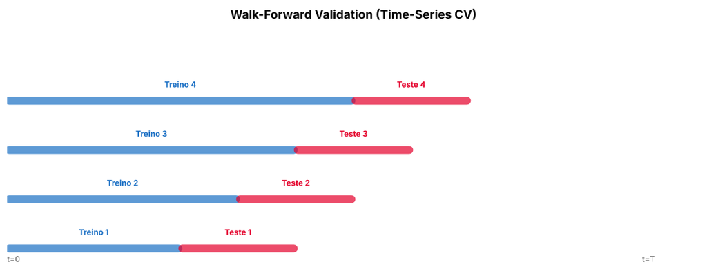

**Nota**

`start=0.5` → começa os backtests na metade da série  
A cada passo: retreina com toda a janela até aquele ponto → prevê `forecast_horizon` passos → avança

## 6 · historical_forecasts()

```python
import logging

# Suprimir logs verbosos do Prophet
logging.getLogger("prophet").setLevel(logging.WARNING)
logging.getLogger("cmdstanpy").disabled = True

# Rodar backtests para os 3 modelos principais
models_backtest = [m_expon, m_prophet_m, m_autoarima_stats]

backtests = [
    model.historical_forecasts(
        series,
        start=0.5,             # começa na metade da série
        forecast_horizon=12,   # prevê 12 meses à frente
    )
    for model in models_backtest
]
```

**Dica**

`start=0.5` usa a primeira metade como treino mínimo e avalia a segunda metade com backtests rolling.  
`forecast_horizon=12` avalia previsões de **12 meses à frente** em cada janela: mais realista que 1 passo.

## 6 · Visualizando os Backtests

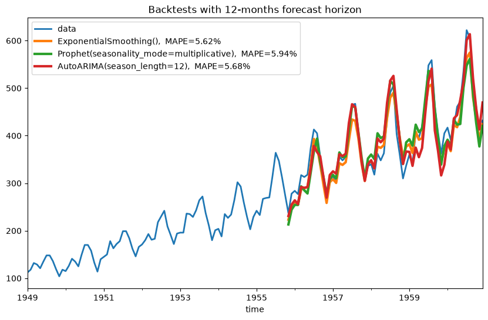

## 6 · Interpretando os Resultados

**Aviso**

O MAPE calculado pelo `historical_forecasts()` é calculado sobre toda a série a partir de `start=0.5`: não apenas no val.  
Para comparação justa com `eval_model()`, calcule o MAPE apenas no período de teste.

# Parte 3 · Métricas e Boas Práticas

*Avaliar corretamente faz toda a diferença*

## 8 · Por que k-fold Convencional Falha?

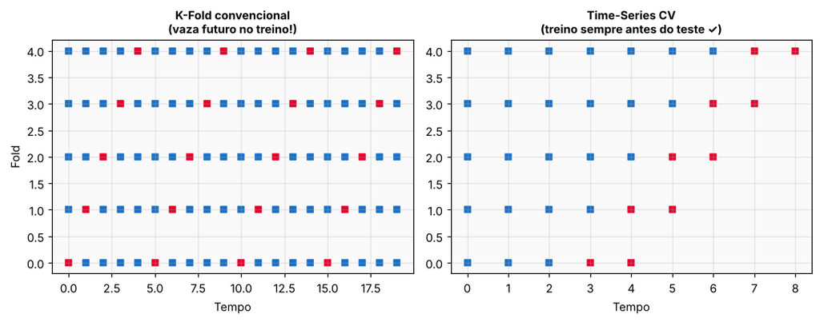

**Aviso**

No k-fold tradicional o modelo pode treinar com dados de 2024 e testar com dados de 2022: **data leakage**, ele vê o futuro.  
O DARTS usa `historical_forecasts()` que garante que **treino sempre precede o teste**.

## 8 · Expanding Window vs Sliding Window

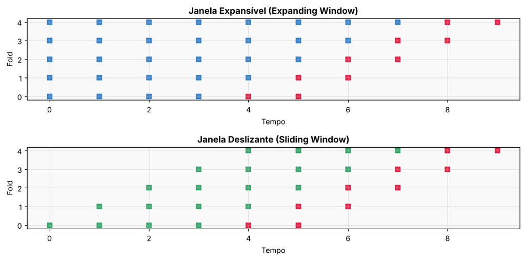

| Método | Treino | Quando usar |
| --- | --- | --- |
| **Expanding** | Cresce a cada split | Série estável, sem quebras estruturais |
| **Sliding** | Janela fixa | Suspeita de quebra \| ex: pós-Covid |

## 8 · Expanding Window vs Sliding Window

```python
# Expanding (padrão no DARTS)
bt_expanding = m_autoarima_stats.historical_forecasts(
    series, start=0.5, retrain=True
)

# Sliding Window: fixar tamanho de treino
bt_sliding = m_autoarima_stats.historical_forecasts(
    series, start=0.5, retrain=True,
    train_length=60   # janela fixa de 60 observações
)

print(f"Expanding | MAPE: {mape(bt_expanding, series):.2f}%")
print(f"Sliding   | MAPE: {mape(bt_sliding,   series):.2f}%")
```

## 9 · Métricas de Erro: Qual Usar?

$$e_{T+i} = y_{T+i} - \hat{y}_{T+i}$$

| Métrica | Fórmula | Quando usar |
| --- | --- | --- |
| **MAE** | $\frac{1}{h}\sum\|e_i\|$ | Erros simétricos, interpretação direta |
| **RMSE** | $\sqrt{\frac{1}{h}\sum e_i^2}$ | Erros grandes são críticos (risco!) |
| **MAPE** | $\frac{100}{h}\sum\left\|\frac{e_i}{y_i}\right\|$ | Comunicar % para gestores |

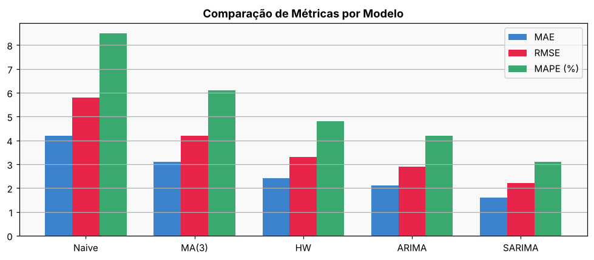

## 10 · Boas Práticas de Validação

1. **Nunca avalie no treino**: use `historical_forecasts()` ou CV
2. **Reserve um teste final**: não toque até o fim do processo
3. **Compare modelos** | use múltiplos horizontes: $h = 1, 6, 12$
4. **Múltiplos horizontes**: avalie $h = 1, 6, 12$ separadamente
5. **Atenção a quebras**: Covid contamina splits que cruzam 2020
6. **Não ajuste no teste**: selecione na CV, avalie no holdout final

**Aviso**

**Armadilha:** testar 10+ modelos e escolher o de menor MAPE no mesmo holdout = overfitting indireto. Use CV para seleção e holdout apenas para avaliação final.

## 11 · Estendendo para Outros Modelos no DARTS

O DARTS suporta muitos outros modelos com a **mesma interface**:

```python
from darts.models import (
    TBATS,                    # sazonalidade múltipla complexa
    Theta                   # competidor do Prophet, muito eficiente
)

# A interface é idêntica para qualquer modelo
m_tbats = TBATS(season_length=12)
bt_tbats = m_tbats.historical_forecasts(
    series,
    start=0.5,
    forecast_horizon=12,
)
print(f"TBATS MAPE: {mape(bt_tbats, series):.2f}%")

m_theta = Theta()
bt_theta = m_theta.historical_forecasts(series, start=0.5, forecast_horizon=12)
print(f"Theta MAPE: {mape(bt_theta, series):.2f}%")
```

# Parte 4 · StatsForecast e Cross-Validation

*Alternativa ultra-rápida ao DARTS para produção em escala*

## 12 · StatsForecast: Por que usar?

O StatsForecast oferece as implementações mais rápidas de AutoARIMA, AutoETS, AutoCES e Theta em Python, com compatibilidade nativa com Spark, Dask e Ray para escala distribuída.

|  | **DARTS** | **StatsForecast** |
| --- | --- | --- |
| **Interface** | OOP, `.fit()` / `.predict()` | Long format (unique_id, ds, y) |
| **CV** | `historical_forecasts()` | `cross_validation()` |
| **Velocidade** | Moderada | ⚡ Muito rápida (backend Numba) |
| **Deep Learning** | ✅ LSTM, N-BEATS, Transformer | ❌ Apenas modelos clássicos |
| **Múltiplas séries** | Uma por vez | ✅ Nativas em paralelo |
| **Produção em escala** | Possível | ✅ Nativo |

**Dica**

**Fluxo recomendado:** use **DARTS** para exploração e entendimento da série, depois valide com **StatsForecast** para produção em escala.

## 13 · StatsForecast: Setup e Modelos

O StatsForecast **não inclui Prophet**: mas propõe alternativas mais rápidas que frequentemente superam o Prophet em séries econômicas:

```python
from statsforecast import StatsForecast
from statsforecast.models import (
    AutoARIMA,      # ARIMA automático: substituto direto do Prophet em muitos casos
    AutoETS,        # Suavização exponencial automática
    AutoTheta,      # Theta automático: competitivo com Prophet
    AutoCES,        # Complex Exponential Smoothing
)

# Preparar dados no formato Nixtla (long format)
df_nixtla = pd.DataFrame({
    'unique_id': 'airline',
    'ds':        AP.index,
    'y':         AP.values
})

# Instanciar com múltiplos modelos
sf = StatsForecast(
    models=[
        AutoARIMA(season_length=12),
        AutoETS(season_length=12),
        AutoTheta(season_length=12),
    ],
    freq='MS',
    n_jobs=-1,
)
```

**Nota**

O StatsForecast foi criado como alternativa ao Prophet: é significativamente mais rápido e frequentemente supera o Prophet em benchmarks de séries econômicas mensais.

## 14 · CV nativa do Prophet: `cross_validation()`

O Prophet tem sua própria função de CV, independente do DARTS e StatsForecast:

```python
from prophet import Prophet
from prophet.diagnostics import cross_validation, performance_metrics
from prophet.plot import plot_cross_validation_metric

# Ajustar Prophet
m = Prophet(seasonality_mode='multiplicative')
m.fit(df_prophet_train)   # df com colunas 'ds' e 'y'

# Cross-validation nativa do Prophet
# initial: treino mínimo | period: espaço entre cortes | horizon: janela de avaliação
df_cv = cross_validation(
    m,
    initial='730 days',    # 2 anos de treino mínimo
    period='180 days',     # novo corte a cada 6 meses
    horizon='365 days',    # avaliar até 1 ano à frente
    parallel='processes'   # paralelizar nos núcleos disponíveis
)

# Métricas por horizonte
df_perf = performance_metrics(df_cv)
print(df_perf[['horizon', 'mae', 'rmse', 'mape']].head(12))

# Visualizar MAPE por horizonte
fig = plot_cross_validation_metric(df_cv, metric='mape')
plt.title('MAPE por horizonte: Prophet CV')
plt.show()
```

**Dica**

Use `parallel='processes'` para séries simples (máquina única).  
Para séries muito grandes, use `parallel='dask'` com um cluster Dask.

## 15 · StatsForecast: `cross_validation()`

```python
# Cross-validation com rolling window
cv_df = sf.cross_validation(
    df=df_nixtla,
    h=12,          # horizonte: 12 meses à frente
    step_size=6,   # novo corte a cada 6 meses
    n_windows=4,   # 4 janelas de avaliação
    refit=True,    # retreina a cada janela (mais realista)
)

print(cv_df.head())
# Colunas: unique_id | ds | cutoff | y | AutoARIMA | AutoETS | AutoTheta
print(f"\nShape: {cv_df.shape}")
print(f"Cutoffs: {cv_df['cutoff'].unique()}")
```

**Nota**

Cada linha = uma previsão feita a partir de um `cutoff` para um passo `ds`.  
A coluna `y` contém o valor **real** observado: use para calcular os erros.

## 16 · Calculando Métricas por Modelo

```python
import numpy as np

# Renomear coluna y para clareza
cv_df = cv_df.rename(columns={'y': 'actual'})

modelos = ['AutoARIMA', 'AutoETS', 'AutoTheta']

print(f"{'Modelo':18s}  {'MAE':>8}  {'RMSE':>8}  {'MAPE':>8}")
print('-' * 52)
for modelo in modelos:
    erros = cv_df['actual'] - cv_df[modelo]
    mae_val  = np.abs(erros).mean()
    rmse_val = np.sqrt((erros**2).mean())
    mape_val = np.abs(erros / cv_df['actual'] * 100).mean()
    print(f"{modelo:18s}  {mae_val:8.1f}  {rmse_val:8.1f}  {mape_val:7.1f}%")
```

## 16 · Visualizando os Resultados

```python
# MAE por horizonte de previsão (step dentro de cada janela)
cv_df['horizonte'] = cv_df.groupby(['unique_id', 'cutoff']).cumcount() + 1

import matplotlib.pyplot as plt

fig, axes = plt.subplots(1, 2, figsize=(13, 4.5))

# MAE por horizonte
for modelo, cor in zip(['AutoARIMA','AutoETS','AutoTheta'],
                        ['#2ecc71','#4a9eff','#ffaa00']):
    mae_h = cv_df.groupby('horizonte').apply(
        lambda g: np.abs(g['actual'] - g[modelo]).mean()
    )
    axes[0].plot(mae_h.index, mae_h.values, lw=2, label=modelo, color=cor)

axes[0].set_title('MAE por Horizonte')
axes[0].set_xlabel('Horizonte h (meses)'); axes[0].set_ylabel('MAE')
axes[0].legend(fontsize=9); axes[0].grid(True)

# Boxplot de erros absolutos por modelo
erros_dict = {m: np.abs(cv_df['actual'] - cv_df[m]).values for m in modelos}
axes[1].boxplot(erros_dict.values(), labels=erros_dict.keys(),
                patch_artist=True,
                medianprops=dict(color='white', lw=2))
axes[1].set_title('Distribuição dos Erros'); axes[1].grid(True, axis='y')
plt.tight_layout(); plt.show()
```

## 17 · Comparando DARTS e StatsForecast na prática

```python
# Pipeline completo: StatsForecast para seleção, depois previsão final
sf.fit(df=df_nixtla)

# Inspecionar modelo AutoARIMA selecionado
modelo_arima = sf.fitted_[0, 0].model_
p, q, P, Q, s, d, D = modelo_arima['arma']
print(f"AutoARIMA selecionou: SARIMA({p},{d},{q})({P},{D},{Q})[{s}]")
print(f"AIC: {modelo_arima['aic']:.2f}")

# Previsão final com IC
previsao = sf.predict(h=12, level=[80, 95])
print(previsao)
```

**Nota**

Tanto `historical_forecasts()` do DARTS quanto `cross_validation()` do StatsForecast implementam **expanding window** por padrão.  
Ambos garantem que o treino sempre precede o teste: sem data leakage.

## 18 · O Ecossistema de Forecasting em Python

Além de DARTS, Prophet e StatsForecast, há outros pacotes relevantes:

| Pacote | Foco | CV | Prophet | Deep Learning |
| --- | --- | --- | --- | --- |
| **DARTS** | Exploração, unified API | `historical_forecasts()` | ✅ wrapper | ✅ LSTM, N-BEATS, TFT |
| **StatsForecast** | Produção, velocidade | `cross_validation()` | ❌ | ❌ |
| **Prophet** | Negócio, tendência flexível | `cross_validation()` nativo | ✅ é o próprio | ❌ |
| **MLForecast** | ML clássico em séries | `cross_validation()` | ❌ | ❌ |
| **NeuralForecast** | Deep Learning | `cross_validation()` | ❌ | ✅ NBEATS, NHITS, TFT |
| **sktime** | scikit-learn API | `ExpandingWindowSplitter` | ✅ wrapper | ✅ via wrappers |

**Nota**

StatsForecast, MLForecast e NeuralForecast formam o **ecossistema Nixtla**: todos usam o mesmo formato de dados (unique_id, ds, y) e podem ser combinados.

## 19 · MLForecast: ML em Séries Temporais

O MLForecast permite usar qualquer modelo scikit-learn (LightGBM, XGBoost, Random Forest) para previsão de séries temporais, com engenharia de features automática (lags, médias móveis) e `cross_validation()` nativo no mesmo formato do StatsForecast.

```python
from mlforecast import MLForecast
from mlforecast.lag_transforms import RollingMean, ExpandingMean
from lightgbm import LGBMRegressor

fcst = MLForecast(
    models=[LGBMRegressor(), ],
    freq='MS',
    lags=[1, 12],                           # lags 1 mês e 12 meses
    lag_transforms={
        1:  [ExpandingMean()],
        12: [RollingMean(window_size=3)],
    },
    date_features=['month'],                # mês como feature
)

# Cross-validation idêntica ao StatsForecast
cv_df = fcst.cross_validation(
    df=df_nixtla, h=12, n_windows=4, step_size=6
)
```

**Dica**

**Quando usar MLForecast:** quando você quer usar modelos de ML (LightGBM, XGBoost) mas com engenharia de features temporal automática: ideal para séries com muitas variáveis exógenas.

## 20 · sktime: API scikit-learn para Séries

O sktime replica a API do scikit-learn para séries temporais, com `ExpandingWindowSplitter` e `SlidingWindowSplitter` para CV temporal, e wrappers para Prophet, ARIMA e modelos do NeuralForecast.

```python
from sktime.forecasting.fbprophet import Prophet as SkProphet
from sktime.forecasting.model_evaluation import evaluate
from sktime.split import ExpandingWindowSplitter

from sktime.performance_metrics.forecasting import (
    MeanAbsoluteError,
    MeanAbsolutePercentageError,
)

cv = ExpandingWindowSplitter(
    initial_window=120,
    step_length=6,
    fh=[1, 6, 12],
)

serie_sk = pd.Series(
    AP["Passengers"].to_numpy(),
    index=pd.PeriodIndex(AP.index, freq="M"),
    name="Passengers",
)

resultados = evaluate(
    forecaster=SkProphet(seasonality_mode="multiplicative"),
    y=serie_sk,
    cv=cv,
    scoring=[
        MeanAbsoluteError(),
        MeanAbsolutePercentageError(),
    ],
)
```

**Dica**

**Quando usar sktime:** quando você quer uma API scikit-learn familiar, usar pipelines de transformação (ex: detrend + model), ou integrar forecasting com outros passos de ML.

## 21 · Resumo: Quando usar cada pacote?

| Situação | Recomendação |
| --- | --- |
| Explorar a série, comparar modelos intuitivamente | **DARTS** |
| Série com sazonalidade complexa, feriados | **Prophet** (nativo ou via DARTS/sktime) |
| Comparar muitos modelos estatísticos rapidamente | **StatsForecast** |
| Usar LightGBM/XGBoost com lags automáticos | **MLForecast** |
| Deep Learning (N-BEATS, NHITS, TFT) | **NeuralForecast** ou **DARTS** |
| API scikit-learn, pipelines complexos | **sktime** |
| Produção com milhares de séries em paralelo | **StatsForecast** + Spark/Ray |

**Nota**

Na prática: comece com **StatsForecast** para baseline rápido, use **DARTS ou Prophet** para exploração, e considere **NeuralForecast** apenas se tiver dados suficientes e os modelos clássicos não saturarem.

## 🏋️ Exercício Proposto

1. Instale: `pip install darts statsforecast prophet`
2. Carregue o **IBC-Br ou Desemprego** via API BCB
3. Rode o `adfuller`: a série é estacionária?
4. **DARTS:** rode `historical_forecasts(start=0.5, forecast_horizon=12)` com ExponSmoothing, Prophet e AutoARIMA
5. **Prophet nativo:** rode `cross_validation(initial='1460 days', period='180 days', horizon='365 days')` e visualize com `plot_cross_validation_metric()`
6. **StatsForecast:** rode `cross_validation(h=12, n_windows=4)` com AutoARIMA, AutoETS e AutoTheta
7. Compare os rankings: Prophet ficou competitivo frente ao AutoARIMA/AutoETS?
8. **Bônus:** meça o tempo de execução de cada abordagem e compare!

**Nota**

O notebook completo da aula está disponível no Colab:  
🔗 colab.research.google.com/drive/1wZXsaNmcZIl1xOqAN1K07hy4tt7KTm02

## 📖 Referências

**DARTS: Time Series Made Easy in Python**  
🔗 [unit8co.github.io/darts](https://unit8co.github.io/darts/)

**StatsForecast: Cross-Validation Tutorial**  
🔗 nixtlaverse.nixtla.io/statsforecast/docs/tutorials/crossvalidation.html

**Automated Model Selection with StatsForecast**  
🔗 nixtla.io/blog/statsforecast-automatic-model-selection

**Forecasting: Principles and Practice** (3ª ed.)  
🔗 [otexts.com/fpp3](https://otexts.com/fpp3/)

**Material do curso**: PADS Insper 2026  
🔗 [padsinsper.github.io/202634-fa](https://padsinsper.github.io/202634-fa/)

**StatsForecast: PyPI**  
🔗 [pypi.org/project/statsforecast](https://pypi.org/project/statsforecast/)

**Forecasting: Principles and Practice** (3ª ed.)  
🔗 [otexts.com/fpp3](https://otexts.com/fpp3/)

# Dúvidas?

*Financial Analytics · PADS · Insper · 2026*